# 431 Class 10

## Posterior Predictive Checks

```r
fit1_diagnostic_plots[[1]]
```

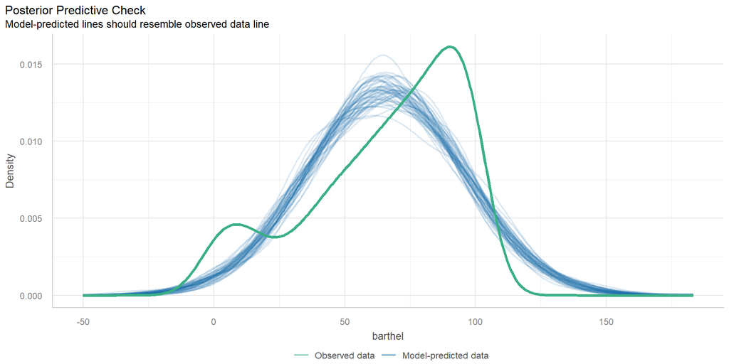

## Box-Cox suggestion?

To use Box-Cox, all values of our outcome `barthel` would have to be strictly positive.

```r
ecare |> reframe(lovedist(barthel))
```

```
# A tibble: 1 × 10
      n  miss  mean    sd   med   mad   min   q25   q75   max
  <int> <int> <dbl> <dbl> <dbl> <dbl> <dbl> <dbl> <dbl> <dbl>
1   847     0  65.4  29.1    75  29.7     0    45    90   100
```

```r
fit1_adj <- lm((barthel+1) ~ e_age, data = ecare)

boxCox(fit1_adj)
```

## Box-Cox suggestion?

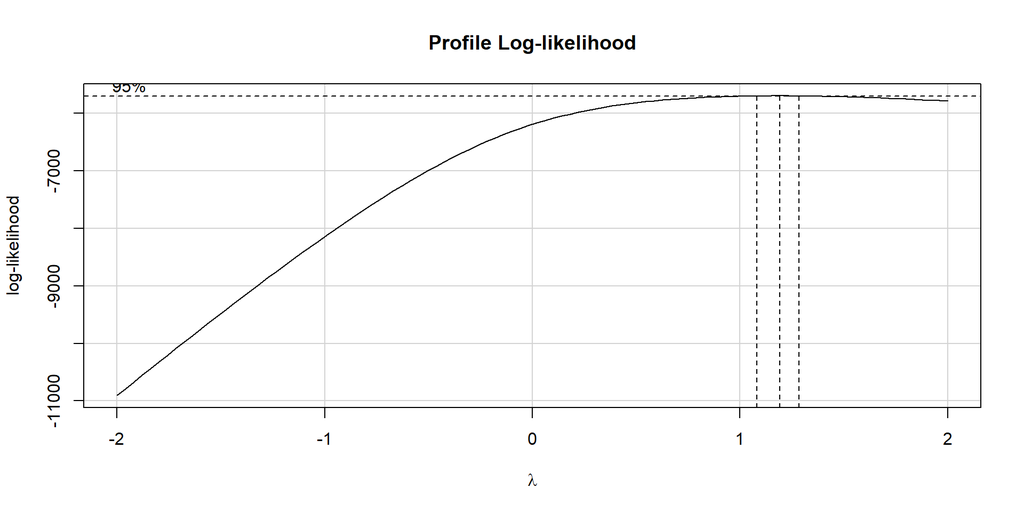

# Question 2

## Question 2

How well can we predict a carer’s negative impact score on the basis of their positive impact score?

- The two scales are described further on the next slide.

```r
ecare |> reframe(lovedist(neg_impact))
```

```
# A tibble: 1 × 10
      n  miss  mean    sd   med   mad   min   q25   q75   max
  <int> <int> <dbl> <dbl> <dbl> <dbl> <dbl> <dbl> <dbl> <dbl>
1   847     0  11.8  3.85    11  2.97     7     9    14    28
```

```r
ecare |> reframe(lovedist(pos_impact))
```

```
# A tibble: 1 × 10
      n  miss  mean    sd   med   mad   min   q25   q75   max
  <int> <int> <dbl> <dbl> <dbl> <dbl> <dbl> <dbl> <dbl> <dbl>
1   847     0  12.5  2.23    13  2.97     5    11    14    16
```

## Caregiver Burden Subscales

- `neg_impact` is higher for carers characterized by avoiding problems, focusing on negative emotions, or engaging in unhealthy behaviors, which are linked to increased psychological distress and other adverse effects.
  - scores in our data range from 7 to 28
- `pos_impact` is higher for carers characterized by adaptive coping strategies focused on finding positive meaning and growth or positive outcomes in stressful situations.
  - scores in our data range from 5 to 16

## Correlation Report

```r
ecare |> select(neg_impact, pos_impact) |> correlation()
```

```
# Correlation Matrix (pearson-method)

Parameter1 | Parameter2 |     r |         95% CI | t(845) |         p
---------------------------------------------------------------------
neg_impact | pos_impact | -0.41 | [-0.47, -0.35] | -13.15 | < .001***

p-value adjustment method: Holm (1979)
Observations: 847
```

- Is the direction of this correlation surprising?
- How about its magnitude?

## Jittered Scatterplot

```r
ggplot(ecare, aes(x = pos_impact, y = neg_impact)) +
  geom_jitter() +
  geom_smooth(method = "loess",
              formula = y ~ x, se = FALSE, col = "blue") +
  geom_smooth(method = "lm",
              formula = y ~ x, se = TRUE, col = "red") +
  labs(title = "EUROFAMCARE data for 847 subjects",
       x = "Positive Impact Score",
       y = "Negative Impact Score",
       caption = "Linear model in red, loess smooth in blue")
```

## Jittered Scatterplot

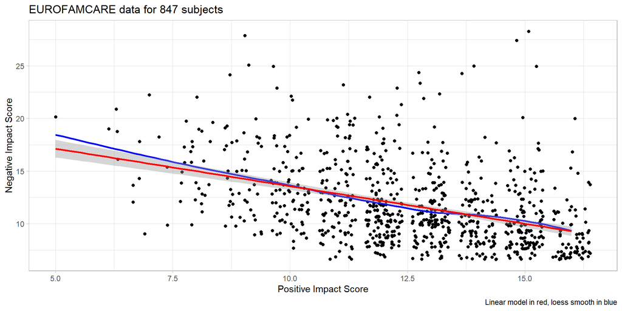

## Fit OLS model

```r
fit2 <- lm(neg_impact ~ pos_impact, data = ecare)
model_parameters(fit2, ci = 0.97, pretty_names = FALSE)
```

```
Parameter   | Coefficient |   SE |         97% CI | t(845) |      p
-------------------------------------------------------------------
(Intercept) |       20.70 | 0.69 | [19.20, 22.19] |  30.07 | < .001
pos_impact  |       -0.71 | 0.05 | [-0.83, -0.59] | -13.15 | < .001
```

- Again, the intercept doesn’t help. All of our `pos_impact` values are between 5 and 16, so we don’t have any useful information about what happens when `pos_impact` = 0.

## Interpret slope estimate

```r
model_parameters(fit2, ci = 0.97, pretty_names = FALSE)
```

```
Parameter   | Coefficient |   SE |         97% CI | t(845) |      p
-------------------------------------------------------------------
(Intercept) |       20.70 | 0.69 | [19.20, 22.19] |  30.07 | < .001
pos_impact  |       -0.71 | 0.05 | [-0.83, -0.59] | -13.15 | < .001
```

- Suppose Harry’s `pos_impact` is one point larger than Sally’s. Our `fit2` model predicts the `neg_impact` for Harry to be 0.71 points less than that of Sally, on average.
- Of course, this assumes Harry and Sally are similar to the subjects in `e_care` and that our linear model `fit2` is correct.

## Interpret slope’s 97% CI

```r
model_parameters(fit2, ci = 0.97, pretty_names = FALSE)
```

```
Parameter   | Coefficient |   SE |         97% CI | t(845) |      p
-------------------------------------------------------------------
(Intercept) |       20.70 | 0.69 | [19.20, 22.19] |  30.07 | < .001
pos_impact  |       -0.71 | 0.05 | [-0.83, -0.59] | -13.15 | < .001
```

- When we generalize beyond study participants to the population they were selected at random from, then our data are compatible (at the 97% confidence level) with population slopes between -0.83 and -0.59, depending on the assumptions of our linear model `fit2` being correct.

## Performance of this model?

```r
model_performance(fit2)
```

```
# Indices of model performance

AIC    |   AICc |    BIC |    R2 | R2 (adj.) |  RMSE | Sigma
------------------------------------------------------------
4534.6 | 4534.6 | 4548.8 | 0.170 |     0.169 | 3.506 | 3.510
```

- What conclusions can we draw here based on the $R^2$ and $\sigma$ estimates?

## Check the fit of our `fit2` OLS model

```r
plot(check_model(fit2, detrend = FALSE))
```

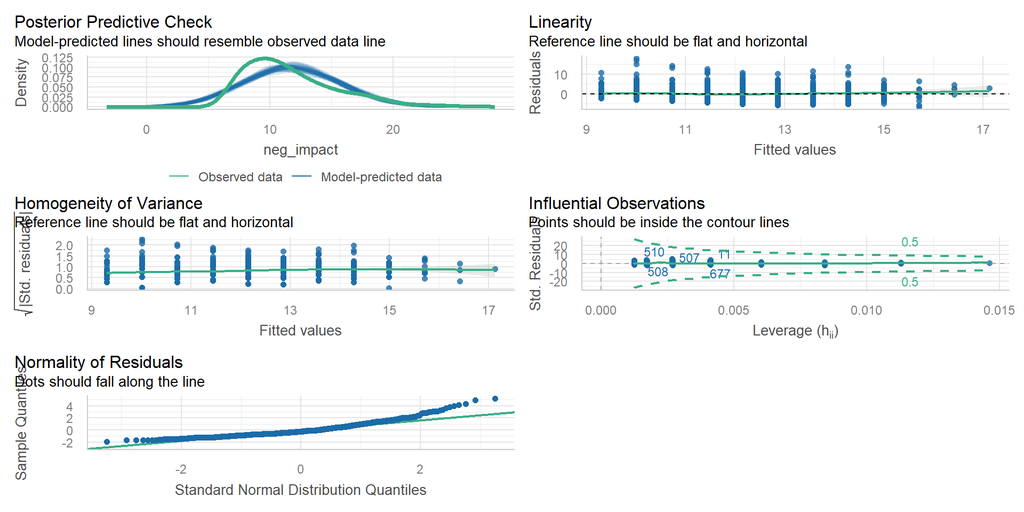